# 都道府県地価調査データによる地価の可視化

佐賀市の例

[岩田真一郎](https://shinichiro-iwata.github.io/)（ [神奈川大学経済学部](https://www.econ.kanagawa-u.ac.jp/)）

2022-07-01作成，2024-04-01改訂

# 目的

公的土地価格は「地価公示」と「都道府県地価調査」に基づき毎年公表される．

- 「[地価公示](https://www.mlit.go.jp/totikensangyo/totikensangyo_fr4_000043.html)」（国土交通省土地鑑定委員会）は1月1日時点の地価を3月に，「都道府県地価調査」（都道府県知事）は7月1日時点の地価を9月に公表．[^1]
  - 「公示価格」（公示地価）は原則として[都市計画区域](https://ja.wikipedia.org/wiki/%E9%83%BD%E5%B8%82%E8%A8%88%E7%94%BB%E5%8C%BA%E5%9F%9F)内（主に[市街化区域](https://ja.wikipedia.org/wiki/%E5%B8%82%E8%A1%97%E5%8C%96%E5%8C%BA%E5%9F%9F)）の土地だけを調査対象とするが，「調査価格」（基準地価）は都市計画区域外（[市街化調整区域](https://ja.wikipedia.org/wiki/%E5%B8%82%E8%A1%97%E5%8C%96%E8%AA%BF%E6%95%B4%E5%8C%BA%E5%9F%9F)の調査地点も増える）の土地も含まれる．
  - したがって，都市全体（広域）の地価分布を知りたい場合は「調査価格」が適している場合もある．そこで，「調査価格」を可視化．
- 佐賀市（グレー枠）の市街化区域（青枠）と市街化調整区域（緑枠）は以下の通り．[^2]

[interactive chart not shown]

ライブラリ：`sf`，`tidyverse`，`rayshader`

```r
library(sf)
library(tidyverse)

#3Dマップ作成のため
library(rayshader)
```

# 調査価格の可視化

**シェープファイルのダウンロード**

- [国土数値情報ダウンロードサービス](https://nlftp.mlit.go.jp/ksj/) > 行政区域（ポリゴン） > 佐賀県 > 世界測地系 令和4年
- [国土数値情報ダウンロードサービス](https://nlftp.mlit.go.jp/ksj/) > 地価公示（ポイント） > 佐賀県 > 「佐賀県」データのダウンロード > 世界測地系 令和4年
- [国土数値情報ダウンロードサービス](https://nlftp.mlit.go.jp/ksj/) > 都道府県地価調査（ポイント） > 佐賀県 > 「佐賀県」データのダウンロード > 世界測地系 令和3年
  - ダウンロードしたZIPファイルは同じフォルダ（ディレクトリ）に納め，ZIPファイルを選択 > 右クリック > すべて展開 > 展開先の選択とファイルの選択 > 展開を実行する．展開後は最初にダウンロードしたZIPファイルを削除．
  - シェープファイルの読込（`read_sf()`）：行政区域を`Saga_map`，公示価格を`Saga_lp1`，調査価格を`Saga_lp2`と名付ける．
    - それぞれのファイルから佐賀市を抜き出す（`filter()`）．
    - 地価は見易いように順番変更（`arrange()`）
    - （背景に福岡県（世界測地系 令和4年）も使用するため，ダウンロード．）

```r
#行政区域（佐賀県）
Saga_map <-
  read_sf("N03-20220101_41_GML/N03-22_41_220101.shp")

#佐賀市選別
Saga_map %>%
  filter(N03_004=="佐賀市") ->
  Saga_shi_map

#行政区域（福岡県）背景に使うため
Fukuoka_map <-
  read_sf("N03-20220101_40_GML/N03-22_40_220101.shp")

#公示価格
Saga_lp1 <-
  read_sf('L01-22_41_GML/L01-22_41.shp')

#佐賀市選別
Saga_lp1 %>%
  filter(L01_022=="41201") ->
  Saga_shi_lp1

#公示価格の順番変更
Saga_shi_lp1 %>%
  arrange(L01_006) ->
  Saga_shi_lp1

#調査価格
Saga_lp2 <-
  read_sf("L02-21_41_GML/L02_21_41.shp")

#佐賀市選別
Saga_lp2 %>%
  filter(L02_020=="41201") ->
  Saga_shi_lp2

#調査価格の順番変更
Saga_shi_lp2 %>%
  arrange(L02_006) ->
  Saga_shi_lp2
```

続いて，都市計画区の内外を区別するため都市地域（ポリゴン）をダウンロード．

- [国土数値情報ダウンロードサービス](https://nlftp.mlit.go.jp/ksj/) > 都市地域（ポリゴン） > 佐賀県 > 世界測地系 平成30年
  - 佐賀市のシェープファイルの読込．`Saga_shi_upa`と名付ける．
    - 都市地域区分コード（`layer_no`）を用いて市街化区域（`1`）を抜き出す．`Saga_shi_ua`と名付ける．
    - 同様にして，市街化調整区域（`2`）を抜き出す．`Saga_shi_uca`と名付ける．

```r
Saga_shi_upa <-
  read_sf("A09-18_41_GML/A09-18_41_GML/shp_file/41201_佐賀市.shp")

Saga_shi_upa %>%
  filter(layer_no==1) ->
  Saga_shi_ua

Saga_shi_upa %>%
  filter(layer_no==2) ->
  Saga_shi_uca
```

**鉄道**

佐賀市の地図上に鉄道（ライン）を示すため，シェープファイルをダウンロード．

- 国土数値情報ダウンロードサービス > 鉄道（ライン） > 全国 > 世界測地系 > 令和2年
  - `railway20`と名付ける．

```r
#2020年の鉄道路線図
railway20 <-
  read_sf("N02-20_GML/N02-20_GML/N02-20_RailroadSection.shp")
```

# 完成図

2枚の地図を並べ，比べる．

- 公示価格の地図を`fig1`，調査価格の地図を`fig2`と名付ける．
  - `theme(legend.position="bottom")`で凡例を地図の下に配置．
  - `patchwork`：図を並べるためのパッケージ．
  - `plot_layout(ncol=2)`で地図を横に2枚並べる．
- 青枠（枠内）が都市計画区域内の市街化区域を，緑枠（枠内）が市都市計画区域内の市街化調整区域を，それ以外（枠黒，枠内白）が都市計画区域外を示す．
  - ポイント数は公示価格が40ポイント，調査価格が51ポイント．
  - 公示価格のポイントは都市計画区域内のみ．
  - 調査価格の地図は公示価格の地図に比べて，市街化調整区域や都市計画区域外のポイント多い．
- 鉄道は`linewidth=0.2`，線の形状は破線`linetype="dashed"`を指示．

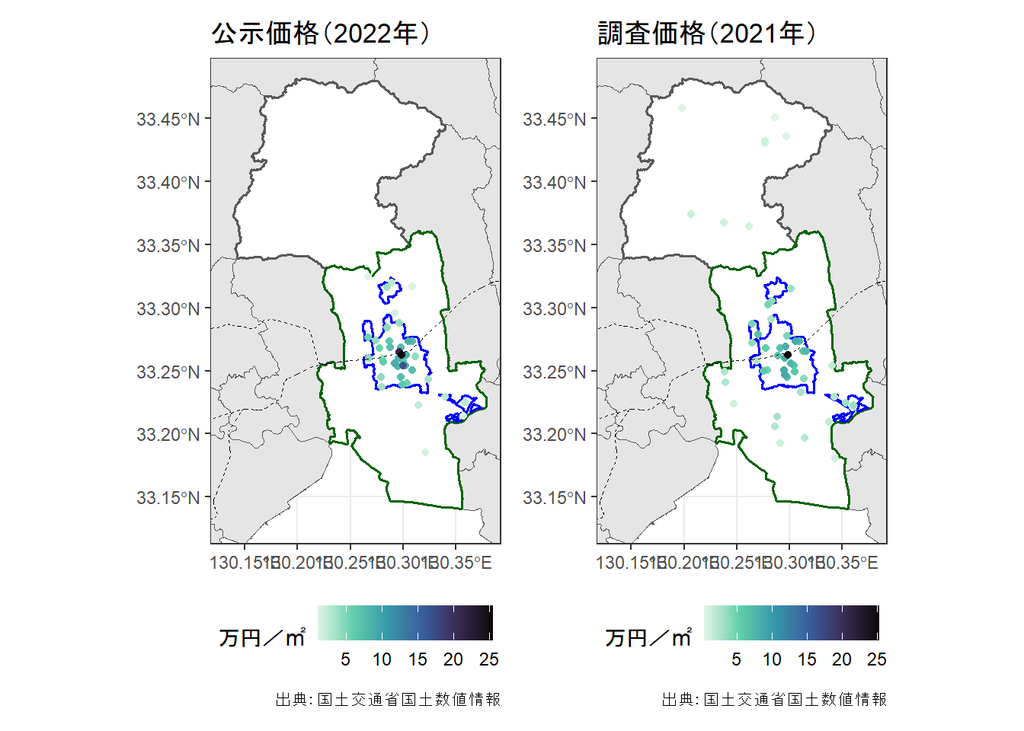

```r
#公示価格
fig1 <-
  ggplot()+
  geom_sf(data=Fukuoka_map)+
  geom_sf(data=Saga_map)+
  geom_sf(data=Saga_shi_map, fill="white",
          linewidth=0.6)+
  geom_sf(data=Saga_shi_uca, fill=NA,
          color="darkgreen", linewidth=0.6)+
  geom_sf(data=Saga_shi_ua, fill=NA,
          color="blue", linewidth=0.6)+
  geom_sf(data=Saga_shi_lp1, aes(color=L01_006/10000))+
  scale_color_viridis_c(option="G", direction=-1)+
  geom_sf(data=railway20, linewidth=0.2,
          linetype="dashed")+
  labs(color="万円／㎡",
       caption="出典：国土交通省国土数値情報")+
  ggtitle("公示価格（2022年）")+
  coord_sf(xlim= c(130.13, 130.38), ylim=c(33.13, 33.48))+
  theme_bw()+
  theme(legend.position="bottom")

#調査価格
fig2 <-
  ggplot()+
  geom_sf(data=Fukuoka_map)+
  geom_sf(data=Saga_map)+
  geom_sf(data=Saga_shi_map, fill="white",
          linewidth=0.6)+
  geom_sf(data=Saga_shi_uca, fill=NA,
          color="darkgreen", linewidth=0.6)+
  geom_sf(data=Saga_shi_ua, fill=NA,
          color="blue", linewidth=0.6)+
  geom_sf(data=Saga_shi_lp2, aes(color=L02_006/10000))+
  scale_color_viridis_c(option="G", direction=-1)+
  geom_sf(data=railway20, linewidth=0.2,
          linetype="dashed")+
  labs(color="万円／㎡",
       caption="出典：国土交通省国土数値情報")+
  ggtitle("調査価格（2021年）")+
  coord_sf(xlim= c(130.13, 130.38), ylim=c(33.13, 33.48))+
  theme_bw()+
  theme(legend.position="bottom")

#図を並べるため
library(patchwork)

#可視化
fig1+fig2+
  plot_layout(ncol=2)
```

# 応用

## 3Dマップ

作成した地図を立体化してみる．地図の立体化の詳細は[3Dマップによる地価の可視化](https://shinichiro-iwata.github.io/geospatial-data-visualization/3D-visualization.html)参照．

- 立体化するためには立体化したい列を`geom_point()`で指示．
  - そのためにポイント（x軸が経度，y軸が緯度）の変数を作成．この点は[バブル・マップによる地価の可視化](https://shinichiro-iwata.github.io/geospatial-data-visualization/bubble-map-visualization.html)参照．

```r
Saga_shi_lp1 %>%
  mutate(x=st_coordinates(geometry)[,1],
         y=st_coordinates(geometry)[,2]) ->
  Saga_shi_lp1

Saga_shi_lp2 %>%
  mutate(x=st_coordinates(geometry)[,1],
         y=st_coordinates(geometry)[,2]) ->
  Saga_shi_lp2
```

**公示地価の可視化**

`ggplot()`で地図を作成し，名前を付ける（`map1`）．

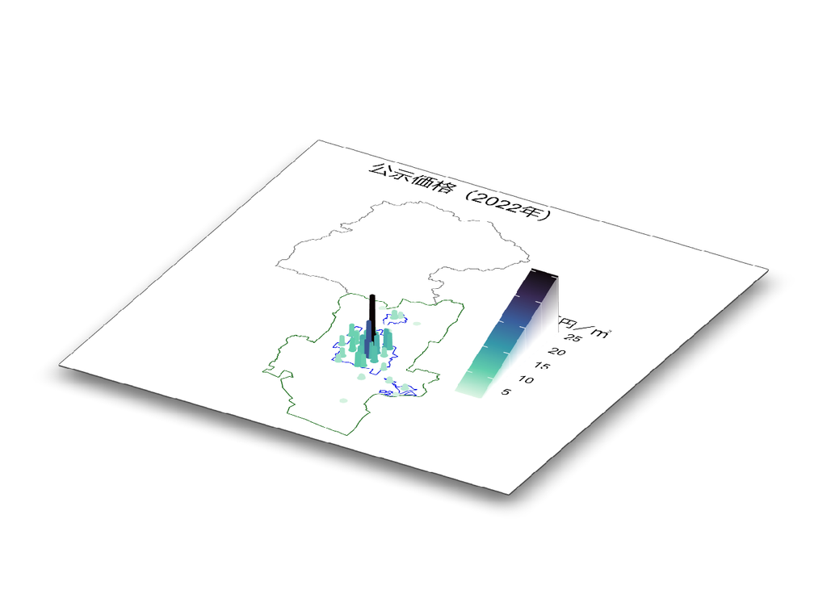

```r
#公示価格の地図
map1 <-
  ggplot()+
  geom_sf(data=Saga_shi_map, fill="white")+
  geom_sf(data=Saga_shi_uca, fill=NA,
          color="darkgreen")+
  geom_sf(data=Saga_shi_ua, fill=NA,
          color="blue")+
  geom_point(data=Saga_shi_lp1,
          aes(x=x, y=y, color=L01_006/10000))+
  scale_color_viridis_c(option="G", direction=-1)+
  labs(color="万円／㎡", x="", y="")+
  ggtitle("公示価格（2022年）")+
  theme_void()+
  theme(
    plot.background=element_rect(fill="white",
                                 color=NA))

map2 <-
  ggplot()+
  geom_sf(data=Saga_shi_map,
          alpha=0, color=NA, fill=NA)+
  geom_sf(data=Saga_shi_uca, alpha=0,
          color=NA, fill=NA)+
  geom_sf(data=Saga_shi_ua, alpha=0,
          color=NA, fill=NA)+
  geom_point(data=Saga_shi_lp1,
          aes(x=x, y=y, color=L01_006/10000))+
  scale_color_viridis_c(option="G", direction=-1)+
  labs(color="万円／㎡", x="", y="")+
  ggtitle("公示価格（2022年）")+
  theme_void()+
  theme(
    plot.background=element_rect(fill="white",
                                 color=NA))

#3D準備
plot_gg(list(map1, map2),
        width=4,
        height=4,
        shadow_intensity=1,
        offset_edges=TRUE,
        soliddepth=0,
        windowsize=c(1400,900),
        zoom=0.6, phi=30, theta=30)

#可視化
render_snapshot()
```

**調査価格の可視化**

同様にして，調査価格も立体化．

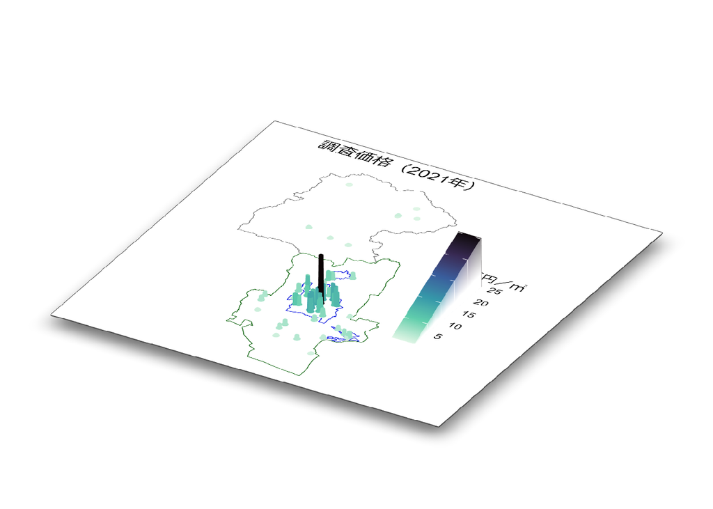

```r
#調査価格の地図
map3 <-
  ggplot()+
  geom_sf(data=Saga_shi_map, fill="white")+
  geom_sf(data=Saga_shi_uca, fill=NA,
          color="darkgreen")+
  geom_sf(data=Saga_shi_ua, fill=NA,
          color="blue")+
  geom_point(data=Saga_shi_lp2,
             aes(x=x, y=y, color=L02_006/10000))+
  scale_color_viridis_c(option="G", direction=-1)+
  labs(color="万円／㎡", x="", y="")+
  ggtitle("調査価格（2021年）")+
  theme_void()+
  theme(
    plot.background=element_rect(fill="white",
                                 color=NA))

map4 <-
  ggplot()+
  geom_sf(data=Saga_shi_map,
          alpha=0, color=NA, fill=NA)+
  geom_sf(data=Saga_shi_uca, alpha=0,
          color=NA, fill=NA)+
  geom_sf(data=Saga_shi_ua, alpha=0,
          color=NA, fill=NA)+
  geom_point(data=Saga_shi_lp2,
             aes(x=x, y=y, color=L02_006/10000))+
  scale_color_viridis_c(option="G", direction=-1)+
  labs(color="万円／㎡", x="", y="")+
  ggtitle("調査価格（2021年）")+
  theme_void()+
  theme(
    plot.background=element_rect(fill="white",
                                 color=NA))

#3D準備
plot_gg(list(map3, map4),
        width=4,
        height=4,
        shadow_intensity=1,
        offset_edges=TRUE,
        soliddepth=0,
        windowsize=c(1400,900),
        zoom=0.6, phi=30, theta=30)

#可視化
render_snapshot()
```

**Rによる地理空間データの可視化**

- チュートリアル[ホーム](https://shinichiro-iwata.github.io/geospatial-data-visualization/)
[^1]: その他に相続税を計算する際に利用される「相続税路線価」や固定資産税を計算する際に利用される「固定資産税評価額」がある．どちらも地価公示を用いて計算される．
[^2]: この図は`mapview()`を用いている．`mapview()`を用いた地理空間データの可視化については[インタラクティブな地図によるデータの可視化](https://shinichiro-iwata.github.io/geospatial-data-visualization/interactive-map-visualization.html)参照．